# Lab-7-Starter

Rename notebook to include your name and ID.  
Submit into **eLearning** and Github (optional)

## Load data

Load data from provided dataset (on eLearning).  
Target column is `y` and it is last column in the dataset.

```python
import pandas as pd
```

```python
data = pd.read_csv("./lab_7_data.csv")
```

```python
data.head()
```

|  | col_0 | col_1 | col_2 | col_3 | col_4 | col_5 | col_6 | col_7 | col_8 | col_9 | ... | col_191 | col_192 | col_193 | col_194 | col_195 | col_196 | col_197 | col_198 | col_199 | y |
| --- | --- | --- | --- | --- | --- | --- | --- | --- | --- | --- | --- | --- | --- | --- | --- | --- | --- | --- | --- | --- | --- |
| 0 | 0.416251 | 0.187764 | 1.392731 | 0.302238 | -0.053183 | -1.598608 | 1.441321 | -0.033600 | -0.163162 | 0.016415 | ... | -1.129246 | -1.874810 | -0.599429 | 1.416135 | -0.176389 | -0.431767 | 1.300498 | 1.531078 | -0.880436 | 0 |
| 1 | -0.890983 | -0.794026 | 0.251547 | 0.010026 | -3.302863 | -0.634802 | -0.650848 | -0.247151 | -0.455664 | 1.074897 | ... | 1.033471 | -0.146153 | -1.416427 | -1.756438 | -0.383269 | -0.387179 | -1.178079 | 0.731939 | -0.794590 | 0 |
| 2 | -0.143477 | -0.216075 | 0.932037 | 0.671241 | 0.175003 | 0.640659 | -1.138888 | -1.394558 | -1.135144 | 0.930762 | ... | -0.687676 | -1.797068 | 0.217285 | -0.120996 | 1.451940 | 0.709817 | 0.057776 | -0.506289 | 1.672958 | 1 |
| 3 | -1.134521 | -0.038174 | -1.332362 | 0.731847 | -0.139031 | -1.840960 | 0.951646 | -0.904985 | -1.168059 | 0.217766 | ... | -0.798943 | 0.713069 | -0.535899 | -0.256444 | -0.084702 | 0.257521 | 0.686006 | -0.908159 | -1.131168 | 1 |
| 4 | 2.142828 | 2.214348 | -0.322788 | -0.811791 | -0.418127 | 0.203688 | -0.219648 | 0.050074 | 0.416546 | -0.482434 | ... | 1.397517 | 0.764536 | -0.906014 | -0.433268 | -0.315009 | -0.253783 | 1.702297 | -0.904033 | -1.016026 | 0 |

5 rows × 201 columns

## Question 1

Use PCA to reduce the size of the feature space while retaining 90% of the explained variance. What is the size of the transformed feature space? (Number of features in the reduced dataset)

You should keep target column `y` as is (don't include in PCA)

```python
from sklearn.linear_model import LogisticRegression
from sklearn.decomposition import PCA
```

```python
pca = PCA(n_components=125)
lr = LogisticRegression(multi_class='auto', solver='liblinear')
```

```python
data_X = data.drop(columns = ['y'])
data_Y = data['y']
X_pca = pca.fit_transform(data_X)
lr.fit(X_pca,data_Y)
```

```
LogisticRegression(solver='liblinear')
```

```python
pca.explained_variance_
```

```
array([60.70071862, 39.9107014 , 34.96853387, 23.43382496, 17.38092425,
        9.79131193,  7.81479038,  6.82491838,  5.92681801,  5.50699275,
        4.91285667,  4.07127084,  3.60957174,  2.82107349,  2.51150639,
        2.00321088,  1.94831265,  1.88326147,  1.85930461,  1.83349631,
        1.80515361,  1.78275936,  1.75221978,  1.74742436,  1.73333844,
        1.70942745,  1.70489767,  1.67935236,  1.67249995,  1.65831583,
        1.63926707,  1.61864026,  1.60413436,  1.58860926,  1.5861431 ,
        1.55851254,  1.54273011,  1.5361435 ,  1.52617298,  1.51624355,
        1.50095032,  1.49407807,  1.48938686,  1.47902583,  1.47093863,
        1.46845424,  1.44882167,  1.43408533,  1.42887317,  1.40587646,
        1.39269912,  1.38573148,  1.38000305,  1.37142953,  1.36839874,
        1.34101989,  1.33437544,  1.32417147,  1.31209006,  1.29769025,
        1.29379489,  1.28745571,  1.28362273,  1.2690893 ,  1.25819211,
        1.24822878,  1.23699863,  1.21883368,  1.21137028,  1.20042359,
        1.19168628,  1.17871292,  1.17211092,  1.16151143,  1.16129604,
        1.15380074,  1.14706414,  1.1330863 ,  1.12835824,  1.11873104,
        1.10885082,  1.10257219,  1.09239409,  1.08635126,  1.07323635,
        1.06810313,  1.05726292,  1.03536197,  1.03097033,  1.02225059,
        1.00951849,  1.00748121,  0.99905176,  0.99321604,  0.98165391,
        0.97289722,  0.9618272 ,  0.95026116,  0.93891062,  0.93040262,
        0.92569448,  0.92032207,  0.917028  ,  0.91099192,  0.90529479,
        0.89743445,  0.88704369,  0.88164414,  0.87364931,  0.86414242,
        0.85658468,  0.84933817,  0.84142507,  0.83149672,  0.81387933,
        0.81024007,  0.8074011 ,  0.80013201,  0.7929307 ,  0.77900027,
        0.77254413,  0.76808427,  0.76533268,  0.74969619,  0.74706256])
```

```python
# Calculate the variance explained by priciple components
print('Variance of each component:', pca.explained_variance_ratio_)
```

```
Variance of each component: [0.14932855 0.09818347 0.08602535 0.05764906 0.04275844 0.0240874
 0.019225   0.01678984 0.01458044 0.01354764 0.01208601 0.01001565
 0.00887983 0.00694006 0.0061785  0.00492806 0.004793   0.00463297
 0.00457404 0.00451055 0.00444082 0.00438573 0.0043106  0.0042988
 0.00426415 0.00420533 0.00419418 0.00413134 0.00411448 0.00407959
 0.00403273 0.00398198 0.0039463  0.0039081  0.00390204 0.00383406
 0.00379524 0.00377903 0.00375451 0.00373008 0.00369246 0.00367555
 0.00366401 0.00363852 0.00361862 0.00361251 0.00356422 0.00352796
 0.00351514 0.00345857 0.00342615 0.00340901 0.00339492 0.00337382
 0.00336637 0.00329901 0.00328267 0.00325757 0.00322784 0.00319242
 0.00318284 0.00316724 0.00315781 0.00312206 0.00309525 0.00307074
 0.00304311 0.00299843 0.00298007 0.00295314 0.00293164 0.00289973
 0.00288349 0.00285741 0.00285688 0.00283844 0.00282187 0.00278748
 0.00277585 0.00275217 0.00272786 0.00271241 0.00268738 0.00267251
 0.00264025 0.00262762 0.00260095 0.00254707 0.00253627 0.00251482
 0.0024835  0.00247848 0.00245775 0.00244339 0.00241495 0.0023934
 0.00236617 0.00233772 0.00230979 0.00228886 0.00227728 0.00226406
 0.00225596 0.00224111 0.0022271  0.00220776 0.0021822  0.00216891
 0.00214925 0.00212586 0.00210727 0.00208944 0.00206997 0.00204555
 0.00200221 0.00199325 0.00198627 0.00196839 0.00195067 0.0019164
 0.00190052 0.00188955 0.00188278 0.00184431 0.00183783]
```

```python
print("The total variance explained is",round(sum(list(pca.explained_variance_ratio_))*100,2))
```

```
The total variance explained is 90.1
```

### The number of features in the reduced data set (or the transformed data set) is 125.

## Question 2

Use original dataset. Split it to Train and Test, 80/20 ratio.

Train a SVC with kernel 'rbf', gamma = 'auto', and C = 10. Target column is `y`.

Report following metrics on test dataset:

- Confusion matrix
- F1 weighted

Set random_state = 142 on all models and functions with this argument.

```python
from sklearn.model_selection import train_test_split
```

```python
X = data.drop(columns=['y'])
Y = data.y
```

```python
X_train,X_test,Y_train, Y_test = train_test_split(X,Y,train_size=0.8,random_state=142)
```

```python
from sklearn.svm import SVC
from sklearn.metrics import ConfusionMatrixDisplay
import matplotlib.pyplot as plt
```

```python
clf = SVC(kernel='rbf', C = 10, gamma='auto', random_state = 142)
```

```python
clf.fit(X_train,Y_train)
```

```
SVC(C=10, gamma='auto', random_state=142)
```

```python
Y_predict = clf.predict(X_test)
```

```
[[105   5]
 [  3  87]]
```

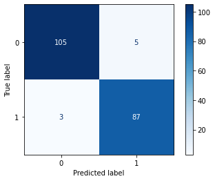

```python
disp = ConfusionMatrixDisplay.from_estimator(
        clf,
        X_test,
        Y_test,
        cmap=plt.cm.Blues)

print(disp.confusion_matrix)
```

```python
 from sklearn.metrics import f1_score
```

```python
print("The weighted F1-score is",f1_score(Y_test, Y_predict, average='weighted'))
```

```
The weighted F1-score is 0.9600362939812481
```

## Question 3

Use dataset with 0.90 variance preserve (Question 1) . Split it to Train and Test, 80/20 ratio.

Train a SVC with kernel 'rbf', gamma = 'auto', and C = 10. Target column is `y`.

Report following metrics on test dataset:

- Confusion matrix
- F1 weighted

Set random_state = 142 on all models and functions with this argument.

How the model results are different from the results in Q2?  
Argue in favor and against using PCA to reduce number of features in this scenario. Provide at least two arguments for each.

```python
X_tr,X_tst,Y_tr, Y_tst = train_test_split(X_pca,data_Y,train_size=0.8,random_state=142)
```

```python
clf_pca = SVC(kernel='rbf', C = 10, gamma='auto', random_state = 142)
```

```python
clf_pca.fit(X_tr,Y_tr)
```

```
SVC(C=10, gamma='auto', random_state=142)
```

```python
Y_pred = clf_pca.predict(X_tst)
```

```
[[103   7]
 [  4  86]]
```

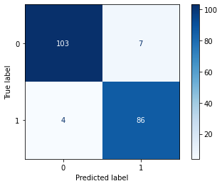

```python
disp1 = ConfusionMatrixDisplay.from_estimator(
        clf_pca,
        X_tst,
        Y_tst,
        cmap=plt.cm.Blues)

print(disp1.confusion_matrix)
```

```python
print("The weighted F1-score is",f1_score(Y_tst, Y_pred, average='weighted'))
```

```
The weighted F1-score is 0.945070635340334
```

PCA model has low f1_score compared to the normal model. Also, the predictions of labels are a bit less accurate as can be seen from the confusion matrix.

Arguments in favor of PCA:

1. Overfitting may occur when there are too many variables. So, PCA helps reduce overfitting
2. We can't run an algorithm on all the features as it will reduce the performance. So,reducing the number of features in the dataset is important. Moreover, all the Principal Components are independent of one another. There is no correlation among them.

Arguments against PCA:

1.After implementing PCA the original features will turn into Principal Components,which are the linear combination of the original features. Principal Components are not as interpretable as original features.

2.Although Principal Components try to cover maximum variance among the features in a dataset, if we don’t select the number of Principal Components with care, it may lead to loss of some information as compared to the original list of features.

# Question 4

Refer to this notebook example: https://github.com/h2oai/h2o-tutorials/blob/master/best-practices/glrm/GLRM_BestPractices.ipynb

Train H2O GLRM model on the input dataset (minus column `y`). Use following parameters to define model:

```
rank2_model = H2OGeneralizedLowRankEstimator(k=2,
                                             model_id = "rank2",
                                             seed = 1234,
                                             loss="Absolute",
                                             transform="standardize",
                                             representation_name="rank2_full")
```

The model will compress dataset to two features only. Our goal is to understand what features ("col0" to col_199") are close to each other. We will use visual two-dimensional graph to do it.

Once you have produced graph, annotate points which are close. Annotate at least two pairs.

If you cannot produce graph, identify two pairs of points using Euclidian distance.

```python
import h2o
try:
    h2o.cluster().shutdown()
except:
    pass
#Limit to 3 threads and 4GB memory
h2o.init(nthreads=3, max_mem_size=8)
```

[output not shown]

[output not shown]

```python
df_h = h2o.import_file("./lab_7_data.csv")
```

```
Parse progress: |████████████████████████████████████████████████████████████████| (done) 100%
```

```python
df_h.describe
```

[output not shown]

```
<bound method H2OFrame.describe of >
```

```python
predictors = df_h.col_names[1:200]
```

```python
df_h["y"] = df_h["y"].asfactor()
response = "y"
```

```python
from h2o.estimators import H2OGeneralizedLowRankEstimator
from h2o.plot import get_matplotlib_pyplot, decorate_plot_result, RAISE_ON_FIGURE_ACCESS
```

```python
rank2_model = H2OGeneralizedLowRankEstimator(k=2,
                                             model_id = "rank2",
                                             seed = 1234,
                                             loss="Absolute",
                                             transform="standardize",
                                             representation_name="rank2_full")
```

```python
rank2_model.train(x=predictors,
              y=response,
              training_frame=df_h)
```

```
glrm Model Build progress: |█████████████████████████████████████████████████████| (done) 100%
Model Details
=============
H2OGeneralizedLowRankEstimator :  Generalized Low Rank Modeling
Model Key:  rank2


Model Summary:
```

|  |  | number_of_iterations | final_step_size | final_objective_value |
| --- | --- | --- | --- | --- |
| 0 |  | 388.0 | 0.000098 | 156910.780964 |

```
ModelMetricsGLRM: glrm
** Reported on train data. **

MSE: NaN
RMSE: NaN
Sum of Squared Error (Numeric): 196530.1680019585
Misclassification Error (Categorical): 0.0

Scoring History:
```

|  |  | timestamp | duration | iterations | step_size | objective |
| --- | --- | --- | --- | --- | --- | --- |
| 0 |  | 2022-04-11 17:21:04 | 0.204 sec | 0.0 | 1.050000 | 158530.280384 |
| 1 |  | 2022-04-11 17:21:05 | 0.219 sec | 1.0 | 1.102500 | 158495.712933 |
| 2 |  | 2022-04-11 17:21:05 | 0.235 sec | 2.0 | 1.157625 | 158471.410734 |
| 3 |  | 2022-04-11 17:21:05 | 0.235 sec | 3.0 | 0.771750 | 158471.410734 |
| 4 |  | 2022-04-11 17:21:05 | 0.251 sec | 4.0 | 0.810338 | 158231.019056 |
| 5 |  | 2022-04-11 17:21:05 | 0.266 sec | 5.0 | 0.850854 | 158027.519649 |
| 6 |  | 2022-04-11 17:21:05 | 0.284 sec | 6.0 | 0.893397 | 157839.896430 |
| 7 |  | 2022-04-11 17:21:05 | 0.301 sec | 7.0 | 0.938067 | 157719.774591 |
| 8 |  | 2022-04-11 17:21:05 | 0.316 sec | 8.0 | 0.984970 | 157704.631643 |
| 9 |  | 2022-04-11 17:21:05 | 0.316 sec | 9.0 | 0.656647 | 157704.631643 |
| 10 |  | 2022-04-11 17:21:05 | 0.332 sec | 10.0 | 0.689479 | 157426.236094 |
| 11 |  | 2022-04-11 17:21:05 | 0.347 sec | 11.0 | 0.723953 | 157333.306553 |
| 12 |  | 2022-04-11 17:21:05 | 0.379 sec | 12.0 | 0.760151 | 157276.264024 |
| 13 |  | 2022-04-11 17:21:05 | 0.401 sec | 13.0 | 0.798158 | 157251.538460 |
| 14 |  | 2022-04-11 17:21:05 | 0.410 sec | 14.0 | 0.532106 | 157251.538460 |
| 15 |  | 2022-04-11 17:21:05 | 0.410 sec | 15.0 | 0.558711 | 157151.628007 |
| 16 |  | 2022-04-11 17:21:05 | 0.426 sec | 16.0 | 0.586646 | 157106.832362 |
| 17 |  | 2022-04-11 17:21:05 | 0.441 sec | 17.0 | 0.615979 | 157084.790613 |
| 18 |  | 2022-04-11 17:21:05 | 0.461 sec | 18.0 | 0.646778 | 157071.931908 |
| 19 |  | 2022-04-11 17:21:05 | 0.477 sec | 19.0 | 0.431185 | 157071.931908 |

```
See the whole table with table.as_data_frame()
```

```python
X = h2o.get_frame("rank2_full")
Y = rank2_model.archetypes()
print(X.shape)
print(len(Y), len(Y[0]))
```

```
(1000, 2)
2 199
```

```python
import pandas as pd

archetypes_cols = rank2_model._model_json["output"]["archetypes"].as_data_frame().reset_index(drop=True).columns.to_list()
archetypes_y = pd.DataFrame({'Arch1':Y[0],'Arch2':Y[1], 'attribute':archetypes_cols[1:]})
archetypes_y.head(n=30)
```

|  | Arch1 | Arch2 | attribute |
| --- | --- | --- | --- |
| 0 | -0.332548 | 0.335782 | col_1 |
| 1 | 0.356035 | -0.313390 | col_2 |
| 2 | 0.184525 | 0.007338 | col_3 |
| 3 | -0.169860 | 0.103513 | col_4 |
| 4 | 0.050397 | -0.026920 | col_5 |
| 5 | 0.068523 | -0.009950 | col_6 |
| 6 | -0.034432 | 0.118100 | col_7 |
| 7 | 0.078315 | -0.070445 | col_8 |
| 8 | -0.054631 | 0.147695 | col_9 |
| 9 | -0.153177 | 0.212024 | col_10 |
| 10 | 0.787702 | -0.728024 | col_11 |
| 11 | 1.871680 | -2.089486 | col_12 |
| 12 | 0.118579 | -0.069102 | col_13 |
| 13 | 0.255732 | -0.145894 | col_14 |
| 14 | -0.629392 | 0.712581 | col_15 |
| 15 | -0.058094 | 0.140741 | col_16 |
| 16 | 0.185033 | -0.167738 | col_17 |
| 17 | 1.831510 | -1.851716 | col_18 |
| 18 | -0.250242 | 0.146951 | col_19 |
| 19 | -0.144112 | 0.182068 | col_20 |
| 20 | -1.327796 | 1.239761 | col_21 |
| 21 | 0.545911 | -0.350681 | col_22 |
| 22 | 0.883229 | -0.838185 | col_23 |
| 23 | -0.172118 | 0.265156 | col_24 |
| 24 | 0.323347 | -0.371953 | col_25 |
| 25 | 0.081474 | -0.000951 | col_26 |
| 26 | 0.097312 | -0.139334 | col_27 |
| 27 | -0.188015 | 0.164592 | col_28 |
| 28 | -0.438224 | 0.439405 | col_29 |
| 29 | 0.203312 | -0.121102 | col_30 |

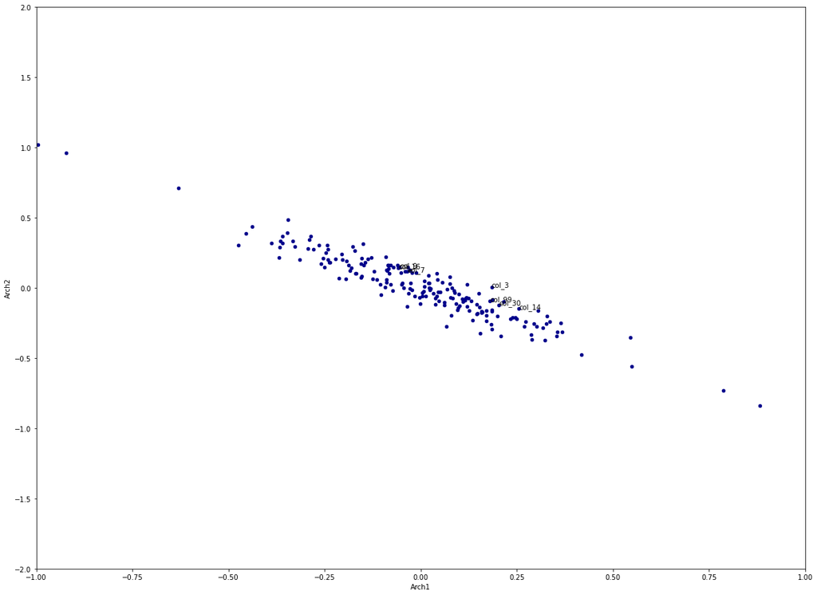

```python
from matplotlib.pyplot import figure
import random
import numpy as np
import matplotlib.pyplot as plt
def change_axis_range():
    # create an integer number array.
    x=np.arange(0,50,1)
    plt.rcParams['figure.figsize'] = [20, 15]

    ax1 = archetypes_y.plot.scatter(x='Arch1',
                                y='Arch2',
                                c='DarkBlue')
    for i, txt in enumerate(archetypes_cols[1:]):
        if txt in ["col_3","col_99","col_9","col_30","col_16","col_7","col_14"]:
            ax1.annotate(txt, (Y[0][i], Y[1][i]))
    plt.xlim(xmin=-1.0,xmax=1.0)
    plt.ylim(ymin=-2.0,ymax=2.0)
    plt.show()
if __name__ == '__main__':

    change_axis_range()
```

##### col_30 and col_14 are close

##### col_7 and col_16 are close

##### col_3 and col_99 are close